# Reproducible Research from JHU, Assignment1

Steve Laurie

1 February 2016

Load dplyr and lattice which we will use for “filter” and plotting.

```r
library(dplyr)
library(lattice)
```

Load the data and have a first look.

```r
rawdata<-read.csv("activity.csv")
dim(rawdata)
```

```
## [1] 17568     3
```

```r
head(rawdata)
```

```
##   steps       date interval
## 1    NA 2012-10-01        0
## 2    NA 2012-10-01        5
## 3    NA 2012-10-01       10
## 4    NA 2012-10-01       15
## 5    NA 2012-10-01       20
## 6    NA 2012-10-01       25
```

How many days do we have data for?

```r
length(unique(rawdata$date))
```

```
## [1] 61
```

Remove rows that have “NA”

```r
Good <- complete.cases(rawdata)
cleandata <- (rawdata[Good,])
dim(cleandata)
```

```
## [1] 15264     3
```

```r
length(unique(cleandata$date))
```

```
## [1] 53
```

We can see that we have removed 8 entire days for which there was no data, leaving us with 53 for further analysis.

### **What is the mean number of total steps taken per day?**

Calculate total number of steps per day

```r
splitByDay<-split(cleandata, cleandata$date)
sapply(splitByDay, function(x){sum(x[, "steps" ])})
```

```
## 2012-10-01 2012-10-02 2012-10-03 2012-10-04 2012-10-05 2012-10-06
##          0        126      11352      12116      13294      15420
## 2012-10-07 2012-10-08 2012-10-09 2012-10-10 2012-10-11 2012-10-12
##      11015          0      12811       9900      10304      17382
## 2012-10-13 2012-10-14 2012-10-15 2012-10-16 2012-10-17 2012-10-18
##      12426      15098      10139      15084      13452      10056
## 2012-10-19 2012-10-20 2012-10-21 2012-10-22 2012-10-23 2012-10-24
##      11829      10395       8821      13460       8918       8355
## 2012-10-25 2012-10-26 2012-10-27 2012-10-28 2012-10-29 2012-10-30
##       2492       6778      10119      11458       5018       9819
## 2012-10-31 2012-11-01 2012-11-02 2012-11-03 2012-11-04 2012-11-05
##      15414          0      10600      10571          0      10439
## 2012-11-06 2012-11-07 2012-11-08 2012-11-09 2012-11-10 2012-11-11
##       8334      12883       3219          0          0      12608
## 2012-11-12 2012-11-13 2012-11-14 2012-11-15 2012-11-16 2012-11-17
##      10765       7336          0         41       5441      14339
## 2012-11-18 2012-11-19 2012-11-20 2012-11-21 2012-11-22 2012-11-23
##      15110       8841       4472      12787      20427      21194
## 2012-11-24 2012-11-25 2012-11-26 2012-11-27 2012-11-28 2012-11-29
##      14478      11834      11162      13646      10183       7047
## 2012-11-30
##          0
```

Visual inspection of the table shows that that the greatest number of steps per day was just over 21k, therefore going to generate a histogram with 22 columns, each representing a 1000 steps.

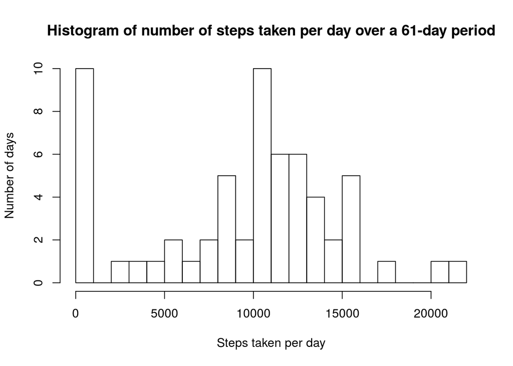

```r
hist(sapply(splitByDay, function(x){sum(x[, "steps" ])}),  breaks=21, main="Histogram of number of steps taken per day over a 61-day period", xlab="Steps taken per day", ylab="Number of days")
```

Calculate mean and median number of steps per day

```r
summary(sapply(splitByDay, function(x){sum(x[, "steps" ])}))
```

```
##    Min. 1st Qu.  Median    Mean 3rd Qu.    Max.
##       0    6778   10400    9354   12810   21190
```

We can see from the summary table above that the **median number of steps per day is 10,400, while the mean is 9,354**. The low mean is due to the large number of days (10), where the total number of steps was less than 1,000 (typically 0).

## Make a time-series plot

Here we are asked to make a time series plot for each moment of the day (across all the days) to see when most steps are taken. So, we can divide this into two steps:

- Get the sum for each of the 288 5-min segements in a day
- Generate and plot the time series

Reusing from above

```r
splitByInterval<-split(cleandata, cleandata$interval)
SumByInterval<-sapply(splitByInterval, function(x){sum(x[, "steps" ])})
```

Generate the plot

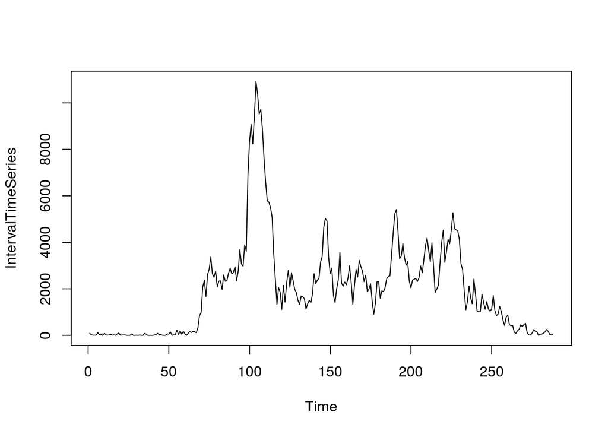

```r
IntervalTimeSeries<-ts(SumByInterval)
plot.ts(IntervalTimeSeries, xy.labels=cleandata$interval)
```

It is clear from the time-series plot that there is a peak in the early morning, around about interval 105.

```r
which.max(IntervalTimeSeries)
```

```
## 835
## 104
```

This shows us that it is exactly interval 104, which corresponds to 835-084a.m.

## Imputing Missing Values

### **Calculate and report the total no. of missing values in the dataset**

We already have this from above when we looked for the complete.cases

```r
table(Good)
```

```
## Good
## FALSE  TRUE
##  2304 15264
```

This indicates that **there are 2304 rows with missing data** i.e. “NAs”

### Devise strategy for filling in all of the missing values - does not need to be sophisticated

I am going to use just the median value for each interval

```r
MedianByInterval<-sapply(splitByInterval, function(x){median(x[, "steps" ])})
```

I found a video that illustrates how to do this: https://www.youtube.com/watch?v=w1t1a_doQoo

Identify the rows which have an NA in the steps column, and replace with the median value for that inteval, in a new dataframe named Impute.

```r
which(is.na(rawdata$steps))
```

```r
MedianRep<-rep(MedianByInterval,61)
Imputed <-cbind.data.frame(rawdata, Median = MedianRep)
Imputed$steps[is.na(Imputed$steps)] <- Imputed$Median[is.na(Imputed$steps)]
splitByDay2<-split(Imputed, Imputed$date)
```

Make a hist of the new data:

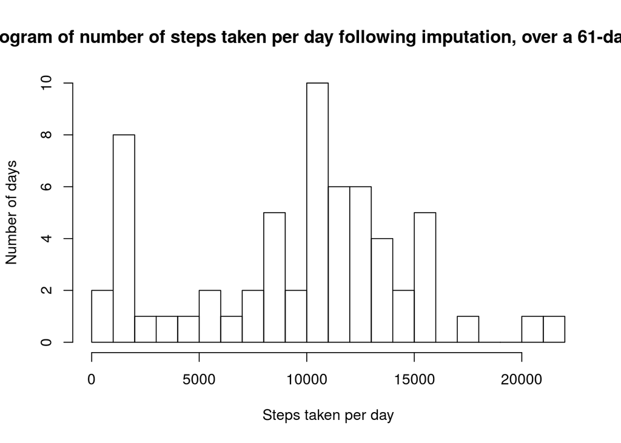

```r
hist(sapply(splitByDay2, function(x){sum(x[, "steps" ])}),  breaks=21, main="Histogram of number of steps taken per day following imputation, over a 61-day period", xlab="Steps taken per day", ylab="Number of days")
```

Check what the mean/median is per day using this new dataset. Main difference appears to be that a lot of the values formerly in bin1 have moved into bin2 - i.e. 1,000-2,000 steps per day.

```r
summary(sapply(splitByDay2, function(x){sum(x[, "steps" ])}))
```

```
##    Min. 1st Qu.  Median    Mean 3rd Qu.    Max.
##      41    6778   10400    9504   12810   21190
```

Naturally the median hasn’t changed, since this was what we used for imputing, but the mean has increased from 9354 to 9504 steps per day.

```r
sapply(splitByDay2, function(x){sum(x[, "steps" ])})
```

```
## 2012-10-01 2012-10-02 2012-10-03 2012-10-04 2012-10-05 2012-10-06
##       1141        126      11352      12116      13294      15420
## 2012-10-07 2012-10-08 2012-10-09 2012-10-10 2012-10-11 2012-10-12
##      11015       1141      12811       9900      10304      17382
## 2012-10-13 2012-10-14 2012-10-15 2012-10-16 2012-10-17 2012-10-18
##      12426      15098      10139      15084      13452      10056
## 2012-10-19 2012-10-20 2012-10-21 2012-10-22 2012-10-23 2012-10-24
##      11829      10395       8821      13460       8918       8355
## 2012-10-25 2012-10-26 2012-10-27 2012-10-28 2012-10-29 2012-10-30
##       2492       6778      10119      11458       5018       9819
## 2012-10-31 2012-11-01 2012-11-02 2012-11-03 2012-11-04 2012-11-05
##      15414       1141      10600      10571       1141      10439
## 2012-11-06 2012-11-07 2012-11-08 2012-11-09 2012-11-10 2012-11-11
##       8334      12883       3219       1141       1141      12608
## 2012-11-12 2012-11-13 2012-11-14 2012-11-15 2012-11-16 2012-11-17
##      10765       7336       1141         41       5441      14339
## 2012-11-18 2012-11-19 2012-11-20 2012-11-21 2012-11-22 2012-11-23
##      15110       8841       4472      12787      20427      21194
## 2012-11-24 2012-11-25 2012-11-26 2012-11-27 2012-11-28 2012-11-29
##      14478      11834      11162      13646      10183       7047
## 2012-11-30
##       1141
```

# What about weekends?

Update dataframe and split in two

```r
Imputed2 <-cbind.data.frame(Imputed, Day = weekdays(as.Date(Imputed$date, abbr=T)))
Imputed2$Weekday <- ifelse(Imputed2$Day == 'lunes'|Imputed2$Day =='martes'|Imputed2$Day =='miércoles'|Imputed2$Day =='jueves'|Imputed2$Day =='viernes',"weekday","weekend")
Weekdays.df<-filter(Imputed2, Weekday=='weekday')
Weekends.df<-filter(Imputed2, Weekday!='weekday')
```

Get summary for each

```r
summary(sapply(split(Weekends.df, Weekends.df$date), function(x){sum(x[, "steps" ])}))
```

```
##    Min. 1st Qu.  Median    Mean 3rd Qu.    Max.
##       0       0       0    2885    1141   15420
```

```r
summary(sapply(split(Weekdays.df, Weekdays.df$date), function(x){sum(x[, "steps" ])}))
```

```
##    Min. 1st Qu.  Median    Mean 3rd Qu.    Max.
##       0       0    7047    6619   11160   21190
```

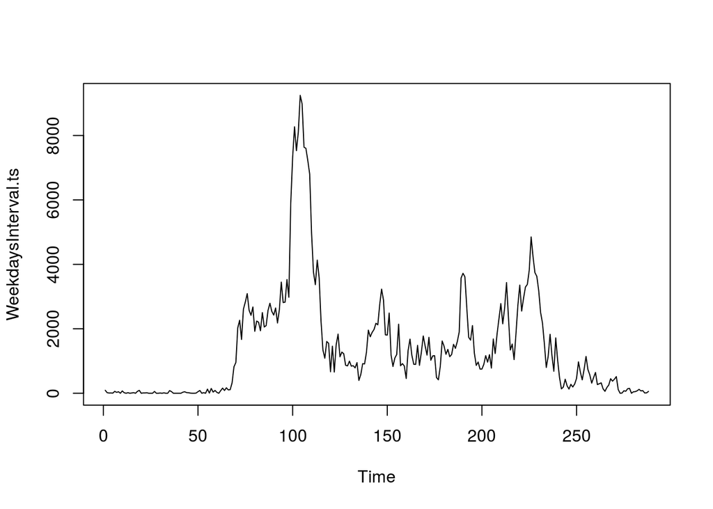

```r
WeekdaysByInterval<-split(Weekdays.df, Weekdays.df$interval)
SumByForWeekdays<-sapply(WeekdaysByInterval, function(x){sum(x[, "steps" ])})
WeekdaysInterval.ts<-ts(SumByForWeekdays)

WeekendsByInterval<-split(Weekends.df, Weekends.df$interval)
SumByForWeekends<-sapply(WeekendsByInterval, function(x){sum(x[, "steps" ])})
WeekendsInterval.ts<-ts(SumByForWeekends)

plot.ts(WeekdaysInterval.ts)
```

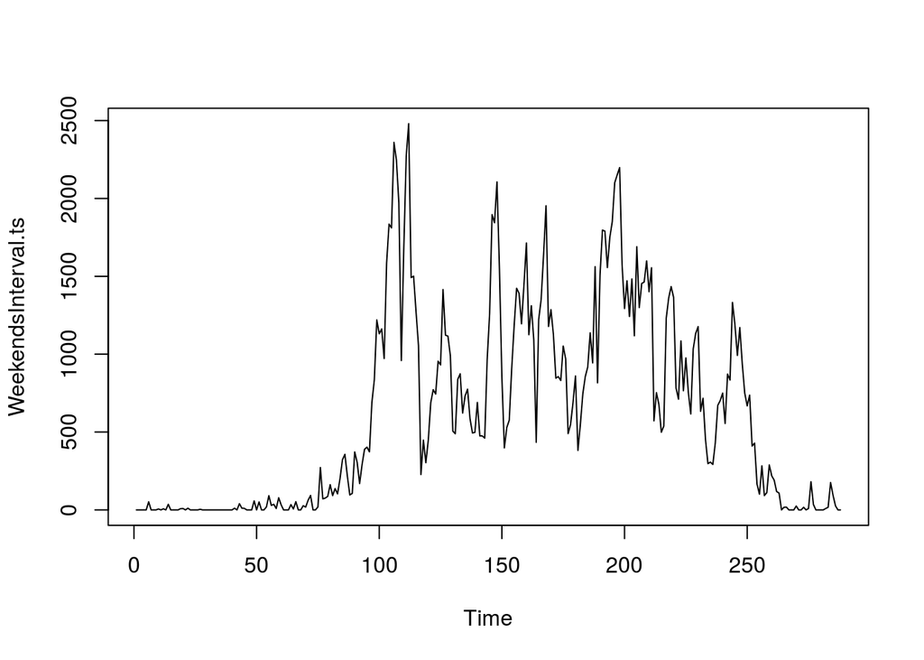

```r
plot.ts(WeekendsInterval.ts)
```

Make the plots - maybe check http://www.fromthebottomoftheheap.net/2013/10/23/time-series-plots-with-lattice-and-ggplot/

```r
Imputed2 <- transform(Imputed2, Weekday = factor(Weekday))
```

```r
class(Imputed2$Weekday)
```

```
## [1] "factor"
```

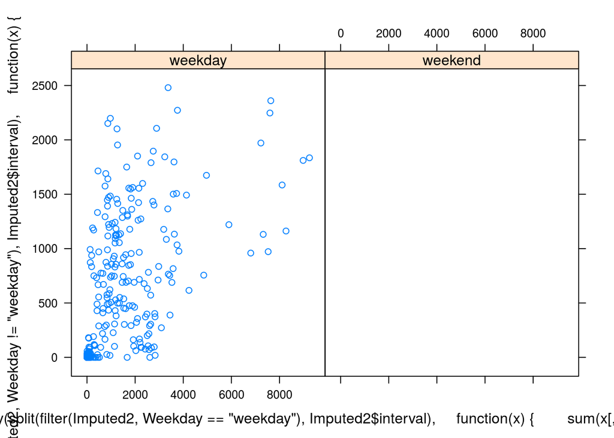

```r
xyplot(
  ts(sapply(split(filter(Imputed2, Weekday!='weekday'), Imputed2$interval)
, function(x){sum(x[, "steps" ])})) ~
ts(sapply(split(filter(Imputed2, Weekday=='weekday'), Imputed2$interval)
, function(x){sum(x[, "steps" ])})) | Imputed2$Weekday, layout = c(2, 1)
)
```

That’s not what I want

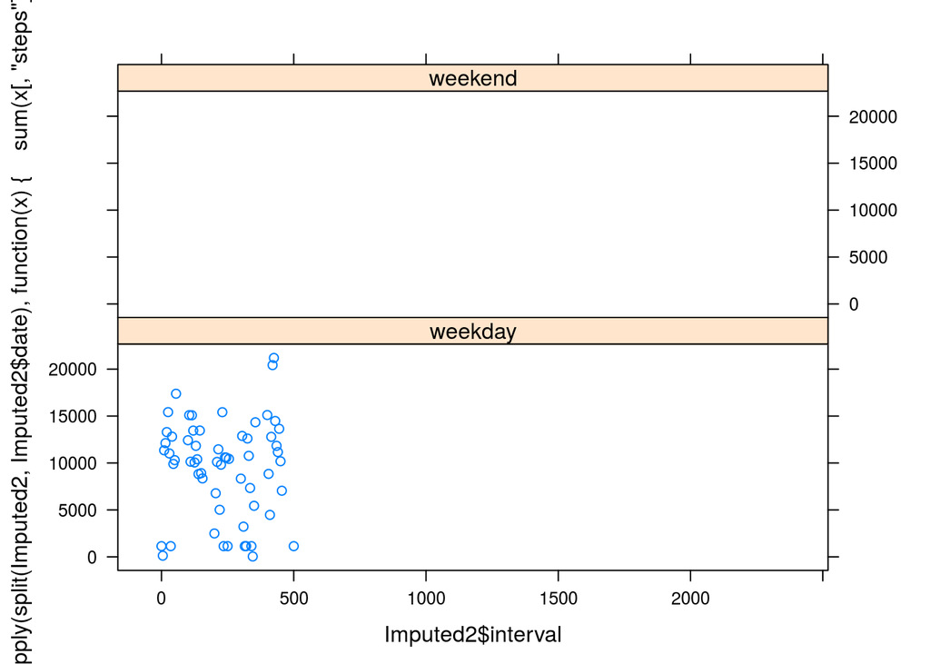

```r
xyplot(
  sapply(split(Imputed2, Imputed2$date), function(x){sum(x[, "steps" ])}) ~ Imputed2$interval| Imputed2$Weekday, layout =c(1,2)
)
```

Neither is this. I have spent a lot of time on this, and I am obviously doing something silly, so I’ll end here.

**Thanks for your time marking**